# Linear and Non-Linear Models (31010) Week 2 Assignment: Optimization

© Yuri Balasanov, iLykei

**This project helps understanding how non-linear optimization of log-likelihood function by the Newton-Raphson method works**

**This assignment is individual**

# 1 Code Your Own Optimizer in R

Use the formulas for the steps of Newton-Raphson method from the lecture notes to code a simple version of optimizer.

The goal of your optimizer is to find a root (crossing of X-axis) of a given function.  
When applied to maximum likelihood estimation this function is going to be derivative of log likelihood function with respect to the estimated parameter: in order to find maximum of a function find root of its derivative.

## 1.1 Writing your optimizer

Optimizer is a function that takes initial guess and an arbitrary objective function name and returns a point on X-axis where the objective functions equals zero.

Let the declaration of the optimizer function be `my.Optimizer<-function(Start.Value,Function.To.Optimize,Epsilon,projectID)`  
where  
`Start.Value` is the initial guess for the optimizer,  
`Function.To.Optimize` is the name of your test function that needs to be optimized,  
`Epsilon` is the stopping criterion, a small number: 0.0001,  
`projectID` is the reserved argument for individual test function in the test below. Parameter `projectID` will be passed to the test function.

The function `my.Optimizer` should repeat iterations of the Newton-Raphson algorithm while $|x_{i+1}-x_{i}|>=\epsilon$, where $x_{i+1}$ is the approximation obtained during the recent iteration and $x_i$ is the approximation obtained during the previous iteration.

You can use any of the loops in R language, for example, `while(cond) expr` where `cond` is the condition of moving to the next iteration ($|x_{i+1}-x_{i}|>=\epsilon$) and `expr` is the sequence of the commands that need to be performed at each iteration.

## 1.2 Checking optimizer

To check your optimizer create a test function that needs to be optimized.

In this project we use one-dimensional optimization, i.e. optimization with respect to only one variable.

Add one more argument to the function, called `projectID`. The meaning of it will become clear in section Test.

Let the declaration of the function be `my.Function<-function(my.X, projectID)`, where `my.X` is a scalar parameter with respect to which the optimization is done. Argument `projectID` is not going to be used until next section.

The function should cross x-axis at least in one point.

For example, you can use

```r
my.Function<-function(my.X,projectID) {
  my.X^2*3-my.X*5-6
}
```

Plot this function.

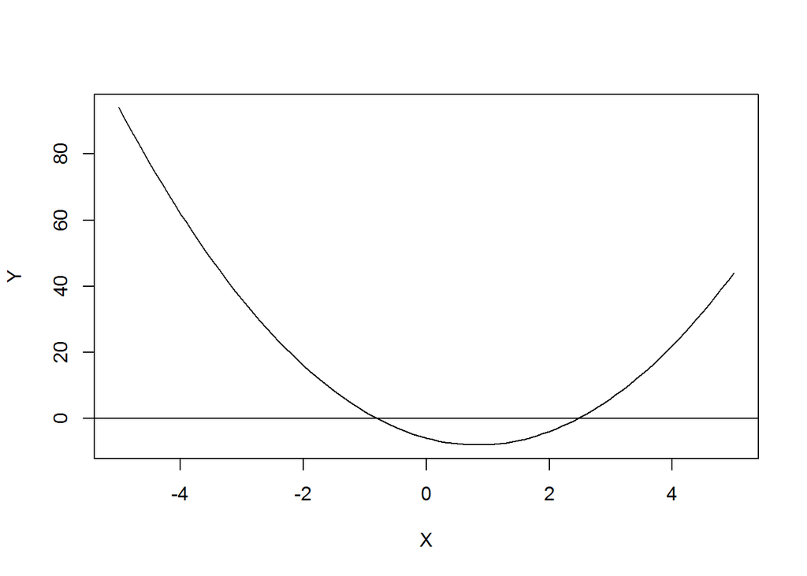

```r
X<-seq(from=-5,to=5,by=.1)
Y<-my.Function(X)
plot(X,Y,type="l")
abline(h=0)
```

**Note that for test you will be given different function to optimize.** That function will use your personal project identificator `projectID` as an argument.  
Be prepared to use an unfamiliar function with your optimizer.

## 1.3 Running your optimizer

Use your optimizer with the test function and initial approximation.

For example, `my.Optimizer(-3,my.Function,Epsilon=.0001)`.  
Make sure you calculate the answer manually to verify the answer.

You can also test the optimizer by running `uniroot()`.

For example,

```r
uniroot(my.Function,lower=-5,upper=+1)
```

```
## $root
## [1] -0.8081429
##
## $f.root
## [1] -1.138463e-06
##
## $iter
## [1] 9
##
## $init.it
## [1] NA
##
## $estim.prec
## [1] 6.103516e-05
```

Try using your optimizer with different start values.

The root returned by your optimizer should be almost the same as the output `$root` of the object returned by `uniroot()`.

Try also to run `optim()`. Explain the difference between the results of two functions: `uniroot()` and `optim()`.  
**How can we reconsile these results?**

# 2 Test

Download [test function](http://ilykei.com/api/fileProxy/documents%2FMScA%20Linear%20and%20Non-Linear%20Models%2031010%2FMScA%2031010%20Lecture%202%2FMScA_Nonlinear_Models_Week2_TestFunction.rds) that will be used to test your optimizer.

[interactive chart not shown]